# Data Analytics - Case Study: Top 250 Movies on IMDb

jrrom

> *Note*: all code for this project is hosted on GitHub at https://github.com/jrrom/data-analytics-top-movies-report, acknowledgments and credits will be given at the end.

# What is Data Analytics?

Data Analytics is the science of extracting insights from raw data. It concerns itself with the cleaning, processing, transforming, modelling and visualising of data with the goal of discovering hidden connections and empowering decision-making.

It is one of the pillars of our modern interconnected existence and it is used everywhere, from the highest levels of governments and companies to the smallest shops near you. It influences the way we view the world and the way the world views us.

It is extremely important to be data literate these days, data is the new gold and we must adapt to this new paradigm. Being data literate and understanding what is being communicated through data can help us identify truths and make our own opinions and judgments on prescient topics.

Learning Data Analytics and the science behind it gives us the foundation to understand our very existence, the world which we inhabit, the systems that we follow and exist under, and finally, ourselves.

## Steps of Data Analytics

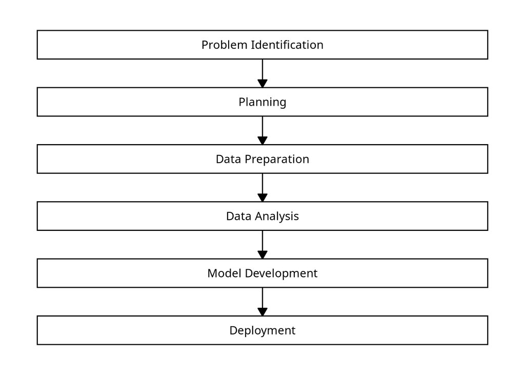

## Types of Data Analytics

- *Descriptive Analytics*: It is an innovative method of data summarisation that allows us to summarise and understand past data. Insights can be generated from past trends which helps us put the past and current situations into context.
- *Predictive Analytics*: It makes predictions using data from current and historical facts. It calculates the probabilities of future events happening. It is useful for taking advantage of historical patterns and can help us identify risks and opportunities.
- *Prescriptive Analytics*: It assists users in finding the optimal solution to a problem. It suggests decisions that can be taken and their implications. It helps us find the best paths forward. It is the third and final phase of business analytics and takes advantage of the descriptive and predictive phases of analytics.

# Case Study: Top 250 Movies on IMDb

## Reasoning

The problem statement of the case study would be to find what factors affect the IMDb rating of a movie and if there are any common links or patterns that emerge when we analyse the top 250 movies. Knowing what cinephiles enjoy in their movies will allow us to understand more about what makes a good movie. It also helps us understand the reviewers and what they themselves enjoy in their movies.

## Methodology

I will be conducting a simple descriptive analysis of the data. The data is obtained from Kaggle and is already semi-preprocessed and ready for use. I will conduct simple tests to figure out basic truths about the data involved and present it here.

Note that the list of movies will always be somewhat inaccurate regarding box office numbers especially with rereleases and other forms of publishing. Budgets for movies also may not always be released.

## Intro

First we can get a general idea of the dataset by doing some preliminary observations. The top movies are as follows:

```
# A tibble: 10 × 2
   originalTitle                                     averageRating
   <chr>                                                     <dbl>
 1 The Shawshank Redemption                                    9.3
 2 The Godfather                                               9.2
 3 The Dark Knight                                             9.1
 4 The Godfather Part II                                       9
 5 12 Angry Men                                                9
 6 The Lord of the Rings: The Return of the King               9
 7 Schindler's List                                            9
 8 The Lord of the Rings: The Fellowship of the Ring           8.9
 9 Pulp Fiction                                                8.8
10 Il buono, il brutto, il cattivo                             8.8
```

It is also very important to get a general overview of the dataset in question. We can do this with a quick summary of the dataset. In Python we can use `.describe()` with `pandas`, however for R we can simply use `summary( ... )`

I am just doing the summary for numerical values since the full table would overflow. I have pre-processed the list to remove problematic budgets.

```
     budget             numVotes       averageRating
 Min.   :   133000   Min.   :  26359   Min.   :8.00
 1st Qu.:  3180000   1st Qu.: 252079   1st Qu.:8.10
 Median : 16000000   Median : 650654   Median :8.20
 Mean   : 41070162   Mean   : 761784   Mean   :8.31
 3rd Qu.: 55000000   3rd Qu.:1136762   3rd Qu.:8.40
 Max.   :356000000   Max.   :3100661   Max.   :9.30
 NA's   :21
```

For reference, here are the maximum and minimum scorers of each value:

| Title | Parameter | Value |
| --- | --- | --- |
| Avengers: Endgame | Budget (USD) (Max) | 356000000.0 |
| Ladri di biciclette | Budget (USD) (Min) | 133000.0 |
| The Shawshank Redemption | Number of Votes (Max) | 3100661.0 |
| La meglio gioventù | Number of Votes (Min) | 26359.0 |
| The Shawshank Redemption | Average Rating (Max) | 9.3 |
| The Incredibles | Average Rating (Min) | 8.0 |
| Into the Wild | Average Rating (Min) | 8.0 |

For the worldwide gross, I had to do a bit of pre-processing since the data is inaccurate for older silent era movies. I have chosen 1941’s Citizen Kane as a benchmark, though it may not be the lowest grossing movie.

| Title | Parameter | Value |
| --- | --- | --- |
| Avengers: Endgame | Worldwide Gross (USD) (Max) | 2799439100 |
| Citizen Kane | Worldwide Gross (USD) (Min) | 1711106 |

## Analysis

### Genres

We can analyse the most common genres to gather insights. Note that a single film can have multiple genres.

| genres | count | prop |
| --- | --- | --- |
| Drama | 183 | 28.460342 |
| Adventure | 64 | 9.953344 |
| Crime | 53 | 8.242613 |
| Action | 49 | 7.620529 |
| Comedy | 44 | 6.842924 |
| Mystery | 31 | 4.821151 |
| Animation | 28 | 4.354588 |
| Biography | 28 | 4.354588 |
| Thriller | 27 | 4.199067 |
| War | 25 | 3.888025 |
| Romance | 23 | 3.576983 |
| Sci-Fi | 20 | 3.110420 |
| Fantasy | 18 | 2.799378 |
| Family | 13 | 2.021773 |
| History | 9 | 1.399689 |
| Horror | 8 | 1.244168 |
| Sport | 6 | 0.933126 |
| Western | 6 | 0.933126 |
| Music | 4 | 0.622084 |
| Film-Noir | 3 | 0.466563 |
| Musical | 1 | 0.155521 |

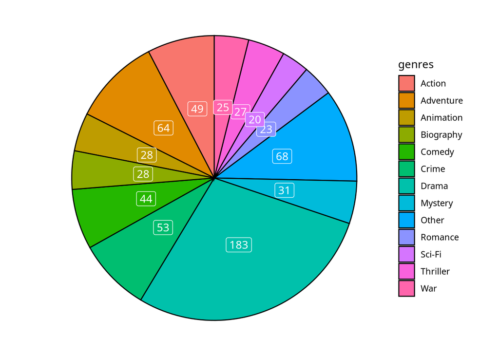

### Content Rating

We can categorise the movies by content rating which gives us the following bar chart after filtering:

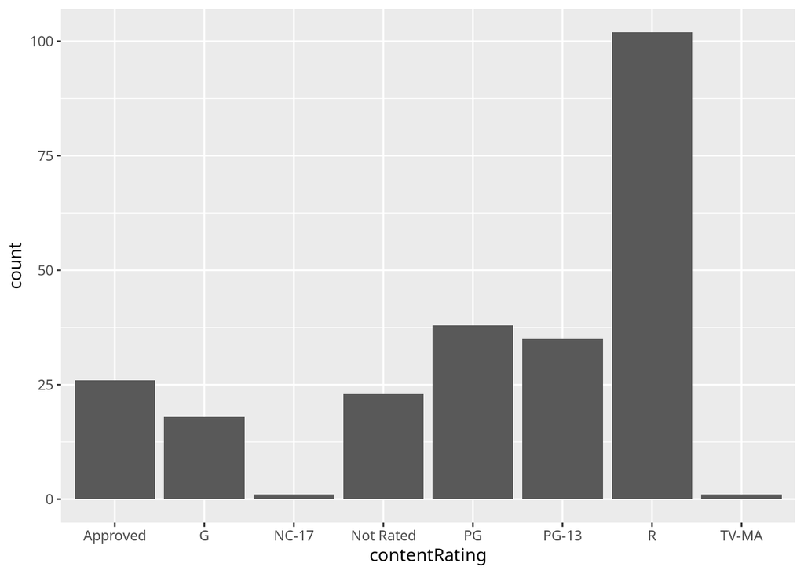

This bar chart actually taught me that before 1968 there was no standardised content rating in the U.S and they operated on an informal classification called the Hays code. It was introduced by the MPPDA (Motion Picture Producers and Distributors of America) and enforced by the PCA (Production Code Administration) from 1934 to 1968. Not Rated means the movie was never submitted to the PCA for approval.

This only applies to old movies, more modern content ratings are also given. Note the fact that the majority of movies belong in the PG, PG-13 and R categories with adults-only (NC-17, TV-MA) and explicitly for kids (G) being underrepresented. Note the presence of a large amount of R rated movies despite the majority of releases released today being PG or PG-13, there is definitely a bias towards R rated movies.

### Budget

The final question I want to find an an answer to, is budget correlated with a good movie? Atleast in the top 250 movies. First I will make a scatterplot of budget vs. average rating. Note that they may be unforeseen inaccuracies with the way that IMDb has entered the budget details of movies.

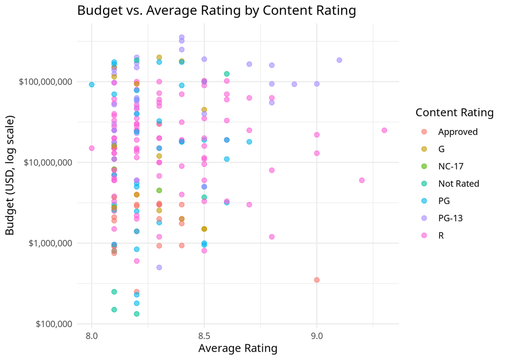

I also wondered what the average budget of each major content rating is.

| Content Rating | Count | Mean Budget (USD) | Median Budget (USD) |
| --- | --- | --- | --- |
| PG-13 | 31 | 105,761,290 | 93,000,000 |
| G | 18 | 49,066,378 | 13,500,000 |
| PG | 37 | 39,470,765 | 16,400,000 |
| Not Rated | 10 | 32,766,300 | 2,695,000 |
| R | 99 | 29,180,474 | 18,500,000 |
| NC-17 | 1 | 4,500,000 | 4,500,000 |
| Approved | 20 | 1,849,106 | 1,826,000 |

Back to topic, to find a definite proof of budget being related to `averageRating`, we must use a test. We note that both variables `budget` and `averageRating` are continuous variables, so we will be using Pearson’s correlation test.

Here are our hypotheses:

- `H0: Budget is not correlated with average rating, retain null hypothesis`
- `HA: Budget is correlated with average rating, reject null hypothesis`

Now we do the test:

```r
print_correlation_test <- function(x, y, alpha = 0.05) {
  cor_test <- cor.test(x, y, method = "pearson")

  cat("Pearson Correlation Test\n")
  cat("========================\n")
  cat("Correlation coefficient (r):", round(cor_test$estimate, 4), "\n")
  cat("t-statistic:", round(cor_test$statistic, 4), "\n")
  cat("Degrees of freedom:", cor_test$parameter, "\n")
  cat("p-value:", format.pval(cor_test$p.value), "\n")
  cat("95% Confidence Interval:",
    round(cor_test$conf.int[1], 4), "to",
    round(cor_test$conf.int[2], 4), "\n"
  )

  df <- cor_test$parameter
  critical_value <- qt(1 - alpha/2, df)
  cat(
    "Critical t-value (alpha=", alpha,
    ", two-tailed):", round(critical_value, 4), "\n", sep=""
  )

  if (abs(cor_test$statistic) > critical_value) {
    cat(
      "\nReject null hypothesis H0 and accept HA hypothesis.",
      " Variables are significantly correlated.\n"
    )
  } else {
    cat(
      "\nFail to reject null hypothesis, ",
      "we retain the null hypothesis H0. No significant correlation detected.\n"
    )
  }
}

print_correlation_test(budget_data$budget, budget_data$averageRating)
```

```
## Pearson Correlation Test
## ========================
## Correlation coefficient (r): 0.1162
## t-statistic: 1.7117
## Degrees of freedom: 214
## p-value: 0.088395
## 95% Confidence Interval: -0.0175 to 0.2459
## Critical t-value (alpha=0.05, two-tailed):1.9711
##
## Fail to reject null hypothesis,  we retain the null hypothesis H0. No significant correlation detected.
```

We use two-tailed test since we don’t know if it is positively correlated or negatively correlated.

# Afterword

Thank you very much for reading my descriptive report, I would like to link all relevant research topics here for perusal.

Tools used:

- https://www.tidyverse.org/
- https://www.r-project.org/
- https://rmarkdown.rstudio.com/
- https://ess.r-project.org/

Resources:

- https://www.kaggle.com/datasets/talhasiddique123/imdb-latest2025-top-250-rated-movies
- https://www.britannica.com/art/Hays-Code